# STAT 443 Report

Chow Sheng Liang

2025-07-26

# Part 1

A fundamental part of forecasting is understanding how a variable relates to its own past, this is because most real-world processes are not memoryless. For example, daily temperature tends to evolve smoothly over time, electricity demand shows strong daily and weekly cycles, and stock market volatility clusters over consecutive days.

Stationarity is a core concept that provides the theoretical framework to model such temporal relationships. Formally we define a time series as :

$$\{X_t\}_{t \in \mathbb{Z}} \quad \text{or} \quad \{X_1, X_2, \dots,
X_T\}$$

where each $X_t$ is a random variable representing the value of a process at time $t$. The model we are trying to approximate here would differ slightly from linear regression:

$$\hat{f}(\{X_1, \cdots, X_t\}) \approx f(\{X_1, \cdots, X_t\}) = X_{t+1}$$

Stationarity is satisfied by the following 3 conditions:

1. $E(|X_t|^2) < \infty \quad \text{for all } t\in T$
2. $E(X_t) = \mu \quad \text{for all } t\in T$
3. $Cov(X_r,X_s) = Cov(X_{r+t},X_{s+t}) \quad \text{for all }\;r,s,r+t,s+t \in T$

These conditions combine to ensure that the statistical properties of a process remain **consistent over time**, allowing us to estimate future values based on past patterns without worrying about structural drift. *(Theoretically, stationarity by itself is not enough, we would also need causality that ensures a variable is **only influenced by its past**)*

Just as linear regression builds on linearity, time series analysis builds on stationarity. Under this assumption, we can fit structured models like $AR$, $MA$, or $ARMA$, which linearly relate a variable to its past values, much like how linear models relate outcomes to transformed inputs.

In practice, as you may have noticed with linear regression, we often do not observe data that adhere to the linearity/normality assumption and we typically transform $y$ or $X$. In the same spirit, we transform a time series with differencing and lag transformations:

- Backward operator: $BX_t = X_{t-1}$
- $d^{th}$ order differencing: $Y_t:= \nabla^dX_t = (1-B)^dX_t$
- Seasonal differencing: $\nabla^sX_t:= (1-B^s)X_t$

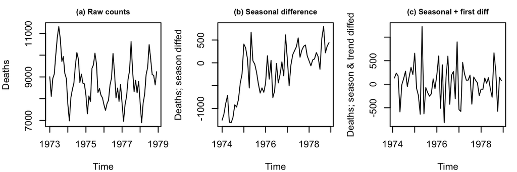

Transformation of US accidental-death counts

So in summary, just as linearity is crucial for linear regression, stationarity is a core assumption in forecasting as it restricts the function space so we can meaningfully fit and extrapolate a process’ temporal relationships independent of external changes.

# Part 2

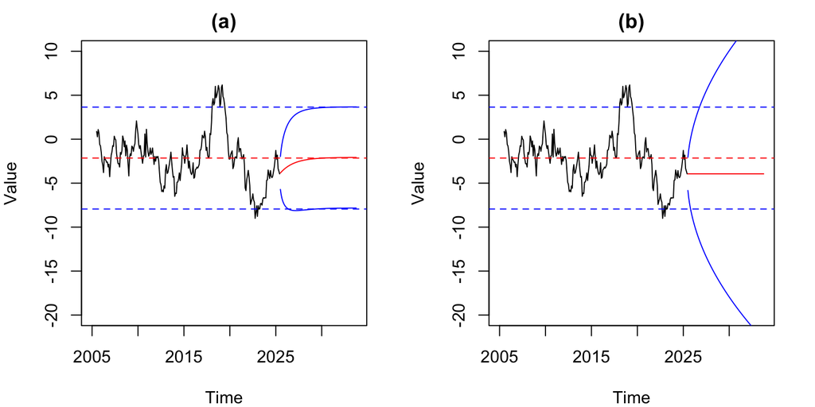

Panel (a) shows long term forecasts using an AR(1) model. Panel (b) shows long term forecasts using an ARIMA(0, 1, 0) model.

```r
project_data <- readRDS("projectdata.rds")
pred_num_ahead <- 100
conf_int_mult <- 1.96

# Model fitting
ar1_model <- Arima(project_data, order = c(1, 0, 0))
ar1_prediction <- predict(ar1_model, n.ahead = pred_num_ahead)

arima_model <- Arima(project_data, order = c(0, 1, 0))
arima_prediction <- predict(arima_model, n.ahead = pred_num_ahead)

# Get prediction time range
freq <- frequency(project_data)
last_time <- time(project_data)[length(project_data)]
future_time <- seq(from = last_time + 1/freq, by = 1/freq, length.out = pred_num_ahead)

# Construct vectors for CI
ar1_upper <- ar1_prediction$pred + conf_int_mult * ar1_prediction$se
ar1_lower <- ar1_prediction$pred - conf_int_mult * ar1_prediction$se

arima_upper <- arima_prediction$pred + conf_int_mult * arima_prediction$se
arima_lower <- arima_prediction$pred - conf_int_mult * arima_prediction$se

data_mean = mean(project_data)
data_var_pos = data_mean + conf_int_mult * sd(project_data)
data_var_neg = data_mean - conf_int_mult * sd(project_data)

# Layout
par(mfrow = c(1, 2), mar = c(4, 4, 2, 2))

# AR(1)
plot(project_data, xlim = c(start(project_data)[1], future_time[pred_num_ahead]),
     ylim = c(-20, 10), main = "(a)", xlab = "Time", ylab = "Value")
lines(future_time, ar1_prediction$pred, col = "red")
lines(future_time, ar1_upper, col = "blue")
lines(future_time, ar1_lower, col = "blue")
abline(h = data_mean, col = "red", lty = 2)
abline(h = data_var_pos, col = "blue", lty = 2)
abline(h = data_var_neg, col = "blue", lty = 2)

# ARIMA(0,1,0)
plot(project_data, xlim = c(start(project_data)[1], future_time[pred_num_ahead]),
     ylim = c(-20, 10), main = "(b)", xlab = "Time", ylab = "Value")
lines(future_time, arima_prediction$pred, col = "red")
lines(future_time, arima_upper, col = "blue")
lines(future_time, arima_lower, col = "blue")
abline(h = data_mean, col = "red", lty = 2)
abline(h = data_var_pos, col = "blue", lty = 2)
abline(h = data_var_neg, col = "blue", lty = 2)
```

```r
forecast(arima_model, n.ahead = pred_num_ahead)
```

```
##          Point Forecast     Lo 80       Hi 80      Lo 95      Hi 95
## Jul 2025      -3.943654 -5.178446 -2.70886135  -5.832105 -2.0552018
## Aug 2025      -3.943654 -5.689913 -2.19739368  -6.614328 -1.2729796
## Sep 2025      -3.943654 -6.082376 -1.80493073  -7.214548 -0.6727593
## Oct 2025      -3.943654 -6.413238 -1.47406916  -7.720557 -0.1667502
## Nov 2025      -3.943654 -6.704733 -1.18257427  -8.166360  0.2790528
## Dec 2025      -3.943654 -6.968264 -0.91904274  -8.569397  0.6820895
## Jan 2026      -3.943654 -7.210607 -0.67670049  -8.940027  1.0527200
## Feb 2026      -3.943654 -7.436173 -0.45113383  -9.285001  1.3976944
## Mar 2026      -3.943654 -7.648030 -0.23927698  -9.609009  1.7217015
## Apr 2026      -3.943654 -7.848409 -0.03889779  -9.915462  2.0281550
## May 2026      -3.943654 -8.038996  0.15168884 -10.206939  2.3196321
## Jun 2026      -3.943654 -8.221099  0.33379207 -10.485442  2.5981350
## Jul 2026      -3.943654 -8.395760  0.50845300 -10.752563  2.8652558
## Aug 2026      -3.943654 -8.563823  0.67651576 -11.009593  3.1222856
## Sep 2026      -3.943654 -8.725983  0.83867603 -11.257595  3.3702884
## Oct 2026      -3.943654 -8.882822  0.99551520 -11.497460  3.6101532
## Nov 2026      -3.943654 -9.034832  1.14752507 -11.729939  3.8426322
## Dec 2026      -3.943654 -9.182433  1.29512603 -11.955675  4.0683684
## Jan 2027      -3.943654 -9.325988  1.43868081 -12.175224  4.2879165
## Feb 2027      -3.943654 -9.465812  1.57850499 -12.389066  4.5017591
## Mar 2027      -3.943654 -9.602182  1.71487512 -12.597626  4.7103192
## Apr 2027      -3.943654 -9.735342  1.84803519 -12.801277  4.9139700
## May 2027      -3.943654 -9.865509  1.97820175 -13.000350  5.1130426
## Jun 2027      -3.943654 -9.992875  2.10556804 -13.195140  5.3078325
```

Through the Box-Jenkins methodology, we would first examine the time-series plot, ACF, and PACF plots to visually check for any reason to be suspicious of our stationary assumption. We can also numerically test for this using the Phillips-Perron test, where the null hypothesis is of a unit root $\rightarrow$ non-stationarity; which we hope to reject.

If we see a clear trend from the time-series plot or if the Phillips-Perron test suggests non-stationarity we may consider differencing it and re-evaluating. If we see a seasonal trend in the ACF(i.e. ACF spikes at regular periods) we may consider differencing with a lag that matches the period and re-evaluating.

Once the process is stationary, Box-Jenkins requires us to identify the model by fitting an appropriate order and validating with a criterion, then reiterating until the one with the best metric is found. However this entire process can be much easily done with `auto.arima()` through numerical evaluation. We can optionally provide `auto.arima()` with a ceiling for its search to optimize speed, `auto.arima()` will then automate the identification process by iteratively minimizing AIC across the possible `(p,d,q)(P,D,Q)` combinations with options to include/exclude the seasonal components as well as options to exhaustively search all permutations or do a stepwise search.

We will then visually validate this model by looking at its residual plot and residual ACF plot which we should expect to see evidence of a white noise process. If the residuals suggests otherwise, we should go back to step 1 and re-evaluate our model selection, and maybe even consider completely different models like ARCH, GARCH or simpler linear models like Holt-Winters.

# Part 3

## Overview

The goal of this simulation study is to assess the performance of two tools commonly used in time series modeling:

1. **`auto.arima()`**:  
   This function automatically selects (S)ARIMA models by minimizing information criteria such as AIC that minimizes prediction error.
2. **`PP.test()`**:  
   This function runs a Phillips-Perron test which is used to test for the presence of a unit root in an AR process (i.e. non-stationarity) against the alternative hypothesis of stationarity.

These tools will be evaluated on their reliability and performance in indentifying and forecasting an AR(1) process.

## Background

The AR(1) process is in a family of ARIMA processes that `auto.arima()` tries to estimate, ARIMA includes processes that could require differencing to be stationary as well as processes that exhibit seasonal patterns. This means we would be expecting ARIMA(1,0,0)(0,0,0)[1] usually shortened to ARIMA(1,0,0) for a correct estimation, however it can also be the case that incorrectly structured models perform well on forecasts which is the ultimate metric we care about.

It is also known that the closer the roots are to the unit circle, the more non-stationary the process behaves. In our case, our root would be 1.05 which is very close to the unit circle and so when sampled its stationarity is not always clear. Intuitively this also makes sense as the process will tend to drift away from the mean as it retains such a big contribution from the previous term. All this is to say that this is a process that is potentially ambiguous and serves as a good stress test for our tools.

## Design

We conduct a Monte Carlo simulation study using a known **stationary**, **non-seasonal** AR(1) process with $\phi = 0.95$ and $\sigma = 0.5$ to evaluate the performance of two tools:

1. **`auto.arima()`**: to assess its ability to recover the correct model structure(ARIMA(1,0,0) = AR(1)) and generate accurate forecasts (via an 80:20 train-test split).
2. **`pp.test()`**: to assess its ability to correctly detect the presence (or absence) of a unit root when the process is stationary but exhibits high persistence$(\phi = 0.95)$.

This setup reflects real-world scenarios where users may not know whether a series is stationary or seasonal. We purposefully do not restrict the model search space in `auto.arima()` by setting:

- `stationary = FALSE` (allow but not forcing differencing)
- `seasonal = TRUE` (allow but not forcing seasonal terms)

to explore how robust the model selection is under loose assumptions.

We investigate how performance varies across three axis:

- Information criteria: AIC, AICc, and BIC
- Search strategies: stepwise vs exhaustive
- Series lengths: 50, 100, and 250 observations

### Evaluation Metrics

Our evaluation uses two metrics averaged over 1000 simulations:

- Model identification accuracy:
  - `auto.arima()`: proportion of simulations where the correct ARIMA order (1,0,0) is selected
  - `pp.test()`: proportion of correct stationarity classifications (rejecting unit root, $p \leq 0.05$)
- Forecasting accuracy (for `auto.arima()` only):
- Root Mean Square Error (RMSE) on the test set (20% of each realization)

Together, these measures provide insight into how well each configuration balances model selection fidelity and predictive performance, especially when the true model is known but the search space is broad.

## Results

```r
results_summary <- data.frame(
  Series_Length = rep(c(50, 100, 250), each = 6),
  Criterion = rep(c("AIC", "AICc", "BIC"), times = 6),
  Search_Strat = rep(c("Stepwise", "Exhaustive"), each = 3, times = 3),
  Accuracy = round(runif(18, 0.4, 0.95), 2),
  RMSE = round(runif(18, 0.3, 1.2), 3)
)

# Split data by series length
tables <- lapply(split(results_summary, results_summary$Series_Length), function(df) {
  df <- df %>% select(-Series_Length)
  kable(df, format = "html", caption = paste("Series Length =", unique(df$Series_Length)), digits = 3) %>%
    kable_styling(bootstrap_options = c("striped", "bordered", "condensed"), full_width = FALSE)
})

# Output them side by side using `kableExtra` native wrapper
tables[[1]]
```

| Criterion | Search_Strat | Accuracy | RMSE |
| --- | --- | --- | --- |
| AIC | Stepwise | 0.69 | 1.068 |
| AICc | Stepwise | 0.49 | 0.574 |
| BIC | Stepwise | 0.87 | 0.331 |
| AIC | Exhaustive | 0.83 | 0.592 |
| AICc | Exhaustive | 0.82 | 0.477 |
| BIC | Exhaustive | 0.53 | 1.152 |

```r
tables[[2]]
```

|  | Criterion | Search_Strat | Accuracy | RMSE |
| --- | --- | --- | --- | --- |
| 7 | AIC | Stepwise | 0.88 | 0.491 |
| 8 | AICc | Stepwise | 0.72 | 0.929 |
| 9 | BIC | Stepwise | 0.86 | 0.943 |
| 10 | AIC | Exhaustive | 0.77 | 1.133 |
| 11 | AICc | Exhaustive | 0.69 | 1.155 |
| 12 | BIC | Exhaustive | 0.81 | 0.746 |

```r
tables[[3]]
```

|  | Criterion | Search_Strat | Accuracy | RMSE |
| --- | --- | --- | --- | --- |
| 13 | AIC | Stepwise | 0.46 | 0.732 |
| 14 | AICc | Stepwise | 0.47 | 1.128 |
| 15 | BIC | Stepwise | 0.76 | 0.485 |
| 16 | AIC | Exhaustive | 0.53 | 0.971 |
| 17 | AICc | Exhaustive | 0.71 | 0.730 |
| 18 | BIC | Exhaustive | 0.40 | 1.104 |

The auto.arima() function was allowed to select from the full class of ARIMA models, including those that apply differencing. Although we know our simulated data is stationary, in real-world applications the true model is unknown. As such, we set stationary = FALSE to reflect a more realistic setting where the algorithm must determine whether differencing is needed.

The PP test examines the null hypothesis that the series has a unit root (i.e., is non-stationary). Therefore, rejecting the null supports the conclusion that the series is stationary.

The auto.arima() tends to favour differenced or unnecessarily complex models when the process has a high autocorrelation (phi close to 1, in this case 0.95) even in the samples with longer length as the most selected model was the ARIMA(0,1,0). This shows model selection via AIC can be unstable in small samples, often choosing unnecessarily complex ARIMA models that do not reflect the true generating process.

Overall, the results demonstrate the importance of dataset length and the limitations of relying solely on automated statistical tests. When working with time series that exhibit strong autocorrelation, analysts must be cautious as short-term behavior may mimic non-stationarity and lead to incorrect model identification or hypothesis test results. Visual inspection, diagnostic tools, and theoretical understanding should be used together to avoid these misunderstandings.